# Untitled

## Importing Data in R

Initialize x

```r
col_names = c(
  "SID",
  "SEASON",
  "NUMBER",
  "BASIN",
  "SUBBASIN",
  "NAME",
  "ISO_TIME",
  "NATURE",
  "LAT",
  "LON",
  "WMO_WIND",
  "WMO_PRES",
  "WMO_AGENCY",
  "TRACK_TYPE",
  "DIST2LAND",
  "LANDFALL"
)

col_types = c(
  "character",
  "integer",
  "integer",
  "character",
  "character",
  "character",
  "character",
  "character",
  "double",
  "double",
  "integer",
  "integer",
  "character",
  "character",
  "integer",
  "integer"
)
data = read.csv(
  file = "ibtracs.NA.list.v04r00.csv",
  colClasses = c(col_types, rep("NULL", 147)),
  stringsAsFactors = FALSE,
  skip = 77876,
  na.strings = c("")
)
colnames(data) = col_names
```

check if initialized correctly

```r
head(data)
```

```
##             SID SEASON NUMBER BASIN SUBBASIN NAME            ISO_TIME NATURE
## 1 1970138N12281   1970     43    NA       CS ALMA 1970-05-17 18:00:00     TS
## 2 1970138N12281   1970     43    NA       CS ALMA 1970-05-17 21:00:00     TS
## 3 1970138N12281   1970     43    NA       CS ALMA 1970-05-18 00:00:00     TS
## 4 1970138N12281   1970     43    NA       CS ALMA 1970-05-18 03:00:00     TS
## 5 1970138N12281   1970     43    NA       CS ALMA 1970-05-18 06:00:00     TS
## 6 1970138N12281   1970     43    NA       CS ALMA 1970-05-18 09:00:00     TS
##      LAT      LON WMO_WIND WMO_PRES WMO_AGENCY TRACK_TYPE DIST2LAND LANDFALL
## 1 11.500 -79.0000       25       NA hurdat_atl       main       224      224
## 2 11.575 -79.0676       NA       NA                  main       235      235
## 3 11.700 -79.2000       25       NA hurdat_atl       main       246      246
## 4 11.900 -79.4349       NA       NA                  main       268      268
## 5 12.100 -79.7000       25       NA hurdat_atl       main       291      291
## 6 12.215 -79.9076       NA       NA                  main       303      303
```

## Adding a MONTH column

```r
data$ISO_TIME = as.POSIXct(data$ISO_TIME)
data$MONTH <- lubridate::month(data$ISO_TIME)
head(data)
```

```
##             SID SEASON NUMBER BASIN SUBBASIN NAME            ISO_TIME NATURE
## 1 1970138N12281   1970     43    NA       CS ALMA 1970-05-17 18:00:00     TS
## 2 1970138N12281   1970     43    NA       CS ALMA 1970-05-17 21:00:00     TS
## 3 1970138N12281   1970     43    NA       CS ALMA 1970-05-18 00:00:00     TS
## 4 1970138N12281   1970     43    NA       CS ALMA 1970-05-18 03:00:00     TS
## 5 1970138N12281   1970     43    NA       CS ALMA 1970-05-18 06:00:00     TS
## 6 1970138N12281   1970     43    NA       CS ALMA 1970-05-18 09:00:00     TS
##      LAT      LON WMO_WIND WMO_PRES WMO_AGENCY TRACK_TYPE DIST2LAND LANDFALL
## 1 11.500 -79.0000       25       NA hurdat_atl       main       224      224
## 2 11.575 -79.0676       NA       NA                  main       235      235
## 3 11.700 -79.2000       25       NA hurdat_atl       main       246      246
## 4 11.900 -79.4349       NA       NA                  main       268      268
## 5 12.100 -79.7000       25       NA hurdat_atl       main       291      291
## 6 12.215 -79.9076       NA       NA                  main       303      303
##   MONTH
## 1     5
## 2     5
## 3     5
## 4     5
## 5     5
## 6     5
```

display structure of your data

```r
str(data, vec.len = 1)
```

```
## 'data.frame':    46053 obs. of  17 variables:
##  $ SID       : chr  "1970138N12281" ...
##  $ SEASON    : int  1970 1970 ...
##  $ NUMBER    : int  43 43 ...
##  $ BASIN     : chr  "NA" ...
##  $ SUBBASIN  : chr  "CS" ...
##  $ NAME      : chr  "ALMA" ...
##  $ ISO_TIME  : POSIXct, format: "1970-05-17 18:00:00" ...
##  $ NATURE    : chr  "TS" ...
##  $ LAT       : num  11.5 ...
##  $ LON       : num  -79 ...
##  $ WMO_WIND  : int  25 NA ...
##  $ WMO_PRES  : int  NA NA ...
##  $ WMO_AGENCY: chr  "hurdat_atl" ...
##  $ TRACK_TYPE: chr  "main" ...
##  $ DIST2LAND : int  224 235 ...
##  $ LANDFALL  : int  224 235 ...
##  $ MONTH     : num  5 5 ...
```

### B) Univariate Exploratory Data Analysis - EDA

```r
data %>%
  group_by(NATURE) %>%
  count()
```

```
## # A tibble: 6 x 2
## # Groups:   NATURE [6]
##   NATURE     n
##   <chr>  <int>
## 1 DS      3149
## 2 ET      4115
## 3 MX         3
## 4 NR       656
## 5 SS      1725
## 6 TS     36405
```

```r
data %>%
  group_by(BASIN) %>%
  count()
```

```
## # A tibble: 2 x 2
## # Groups:   BASIN [2]
##   BASIN     n
##   <chr> <int>
## 1 EP      309
## 2 NA    45744
```

## C.1) Are hurricanes becoming more frequent?

- get all the hurricanes from the data. -> group by SID, and filter out any unique storm SID such that its max(WMO_WIND) doesn’t exceed 64 knots.

```r
hurricanes = data %>%
  drop_na(WMO_WIND) %>%
  group_by(SID) %>%
  filter(!any(max(WMO_WIND) <= 64))

hurricanes
```

```
## # A tibble: 13,449 x 17
## # Groups:   SID [331]
##    SID       SEASON NUMBER BASIN SUBBASIN NAME  ISO_TIME            NATURE   LAT
##    <chr>      <int>  <int> <chr> <chr>    <chr> <dttm>              <chr>  <dbl>
##  1 1970138N~   1970     43 NA    CS       ALMA  1970-05-17 18:00:00 TS      11.5
##  2 1970138N~   1970     43 NA    CS       ALMA  1970-05-18 00:00:00 TS      11.7
##  3 1970138N~   1970     43 NA    CS       ALMA  1970-05-18 06:00:00 TS      12.1
##  4 1970138N~   1970     43 NA    CS       ALMA  1970-05-18 12:00:00 TS      12.3
##  5 1970138N~   1970     43 NA    CS       ALMA  1970-05-18 18:00:00 TS      12.5
##  6 1970138N~   1970     43 NA    CS       ALMA  1970-05-19 00:00:00 TS      13
##  7 1970138N~   1970     43 NA    CS       ALMA  1970-05-19 06:00:00 TS      13.5
##  8 1970138N~   1970     43 NA    CS       ALMA  1970-05-19 12:00:00 TS      14
##  9 1970138N~   1970     43 NA    CS       ALMA  1970-05-19 18:00:00 TS      14.5
## 10 1970138N~   1970     43 NA    CS       ALMA  1970-05-20 00:00:00 TS      15.5
## # ... with 13,439 more rows, and 8 more variables: LON <dbl>, WMO_WIND <int>,
## #   WMO_PRES <int>, WMO_AGENCY <chr>, TRACK_TYPE <chr>, DIST2LAND <int>,
## #   LANDFALL <int>, MONTH <dbl>
```

```r
raw_year_count = hurricanes %>%
  group_by(SEASON) %>%
  summarise(count = n_distinct(SID))
raw_year_count
```

```
## # A tibble: 51 x 2
##    SEASON count
##     <int> <int>
##  1   1970     5
##  2   1971     6
##  3   1972     3
##  4   1973     4
##  5   1974     4
##  6   1975     6
##  7   1976     6
##  8   1977     5
##  9   1978     5
## 10   1979     6
## # ... with 41 more rows
```

For better visual representation, this can be represented as geom_line plot.

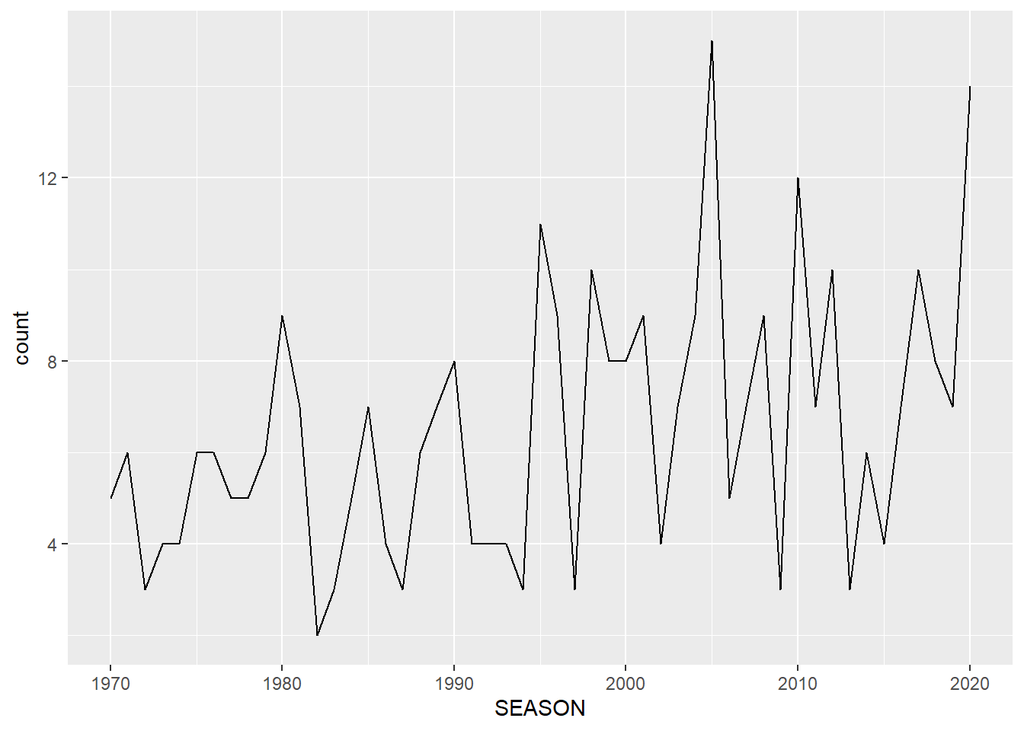

```r
ggplot(raw_year_count, aes(SEASON, count)) + geom_line()
```

But, we don’t know the exact tendency by seeing the graph’s fluctuation; plotting linear regression will be helpful visualizing the result.

visualizing with geom_smooth

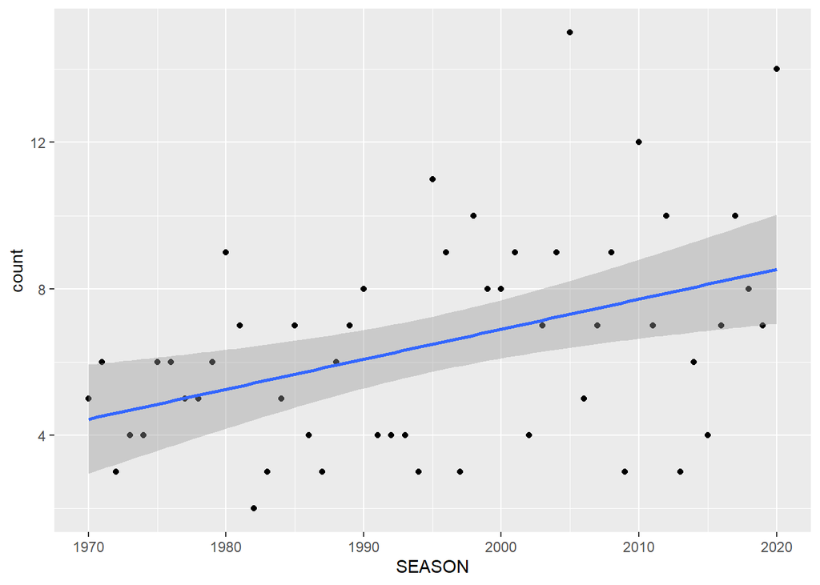

```r
ggplot(raw_year_count, aes(SEASON, count)) +
  geom_point() +
  geom_smooth(method='lm')
```

- Statistics

```r
x_season = raw_year_count$SEASON
y_count = raw_year_count$count

relation = lm(formula = y_count ~ x_season)
summary(relation)
```

```
##
## Call:
## lm(formula = y_count ~ x_season)
##
## Residuals:
##     Min      1Q  Median      3Q     Max
## -4.9644 -2.1044 -0.0979  1.5659  7.6908
##
## Coefficients:
##               Estimate Std. Error t value Pr(>|t|)
## (Intercept) -156.90121   50.91341  -3.082  0.00337 **
## x_season       0.08190    0.02552   3.209  0.00235 **
## ---
## Signif. codes:  0 '***' 0.001 '**' 0.01 '*' 0.05 '.' 0.1 ' ' 1
##
## Residual standard error: 2.683 on 49 degrees of freedom
## Multiple R-squared:  0.1737, Adjusted R-squared:  0.1568
## F-statistic:  10.3 on 1 and 49 DF,  p-value: 0.002349
```

Conclusion: - The number of hurricanes seems to have some positive correlation over the years , meaning that the number of hurricanes have occurred is likely to increase over years with statistical significance.

## C.2) Are hurricanes getting stronger?

- Firstly, I need to define what ‘strong’ means. Here in the univariate analysis, I took WMO_WIND as a way to measure the strength.
- As a next step, I cleaned the data by dropping NA value in WMO_WIND and take average of each specific hurricane. I use hurricane data set defined in the question above.

```r
hurricane_mean = hurricanes %>%
  drop_na(WMO_WIND) %>%
  group_by(SID, SEASON) %>%
  summarise_at(vars(WMO_WIND), list(WMO_WIND_mean = mean))

hurricane_mean
```

```
## # A tibble: 331 x 3
## # Groups:   SID [331]
##    SID           SEASON WMO_WIND_mean
##    <chr>          <int>         <dbl>
##  1 1970138N12281   1970          30.8
##  2 1970212N18278   1970          54.4
##  3 1970252N15277   1970          51.2
##  4 1970286N25292   1970          52.8
##  5 1970294N34312   1970          49.8
##  6 1971216N31297   1971          39.4
##  7 1971223N27280   1971          42.9
##  8 1971247N28273   1971          40
##  9 1971249N11302   1971          52.1
## 10 1971249N26289   1971          59.0
## # ... with 321 more rows
```

Before we move on, I will present max and mean strength for each year and take them for different interpretations, since change in max and change in mean strength might represent different meanings.

```r
hurricane_max_mean_by_year =
  hurricane_mean %>%
  group_by(SEASON) %>%
  summarise(WIND_max = max(WMO_WIND_mean), WIND_mean = mean(WMO_WIND_mean))

hurricane_max_mean_by_year
```

```
## # A tibble: 51 x 3
##    SEASON WIND_max WIND_mean
##     <int>    <dbl>     <dbl>
##  1   1970     54.4      47.8
##  2   1971     59.0      47.5
##  3   1972     54.9      47.5
##  4   1973     60.8      56.1
##  5   1974     67.5      57.1
##  6   1975     67.1      51.7
##  7   1976     68.1      58.3
##  8   1977     72        49.8
##  9   1978     79.6      56.1
## 10   1979     82.8      50.7
## # ... with 41 more rows
```

- Visualize

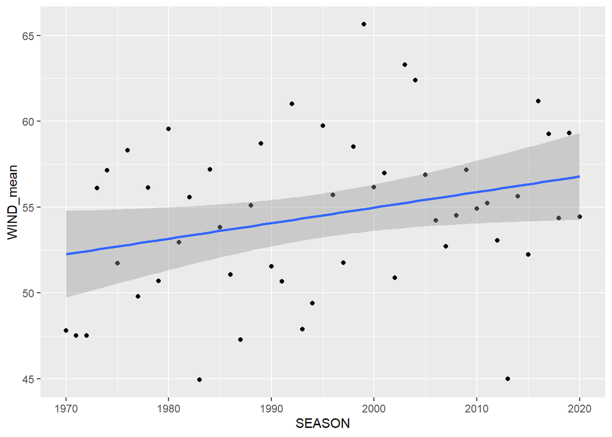

```r
ggplot(hurricane_max_mean_by_year, aes(x = SEASON, y = WIND_mean)) +
  geom_point() +
  geom_smooth(method='lm')
```

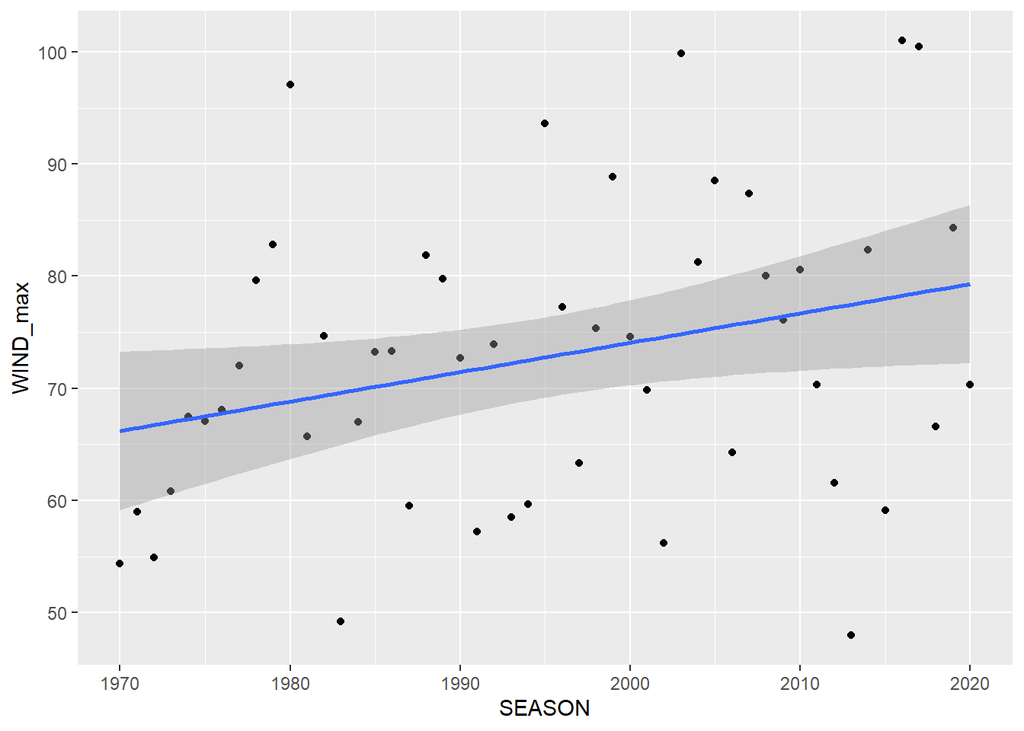

```r
ggplot(hurricane_max_mean_by_year, aes(x = SEASON, y = WIND_max)) +
  geom_point() +
  geom_smooth(method='lm')
```

-statistics

```r
x_season = hurricane_max_mean_by_year$SEASON
y_mean = hurricane_max_mean_by_year$WIND_mean
y_max = hurricane_max_mean_by_year$WIND_max

mean_regression = lm(formula = y_mean ~ x_season)
max_regression = lm(formula = y_max ~ x_season)

summary(mean_regression)
```

```
##
## Call:
## lm(formula = y_mean ~ x_season)
##
## Residuals:
##      Min       1Q   Median       3Q      Max
## -11.1456  -2.9819  -0.6013   3.3582  10.7657
##
## Coefficients:
##               Estimate Std. Error t value Pr(>|t|)
## (Intercept) -126.13940   86.30369  -1.462   0.1502
## x_season       0.09056    0.04326   2.093   0.0415 *
## ---
## Signif. codes:  0 '***' 0.001 '**' 0.01 '*' 0.05 '.' 0.1 ' ' 1
##
## Residual standard error: 4.547 on 49 degrees of freedom
## Multiple R-squared:  0.08209,    Adjusted R-squared:  0.06336
## F-statistic: 4.382 on 1 and 49 DF,  p-value: 0.04151
```

```r
summary(max_regression)
```

```
##
## Call:
## lm(formula = y_max ~ x_season)
##
## Residuals:
##      Min       1Q   Median       3Q      Max
## -29.5138 -10.5384   0.5523   5.7155  28.2410
##
## Coefficients:
##              Estimate Std. Error t value Pr(>|t|)
## (Intercept) -449.8204   241.6660  -1.861   0.0687 .
## x_season       0.2619     0.1211   2.162   0.0355 *
## ---
## Signif. codes:  0 '***' 0.001 '**' 0.01 '*' 0.05 '.' 0.1 ' ' 1
##
## Residual standard error: 12.73 on 49 degrees of freedom
## Multiple R-squared:  0.08712,    Adjusted R-squared:  0.06849
## F-statistic: 4.676 on 1 and 49 DF,  p-value: 0.03549
```

## C.3) 2019 Atlantic Hurricane Season

# a) The 2019 atlantic hurricane season had 20 tropical cyclones, of which 18 were named storms.

```r
data %>%
  filter(SEASON == 2019 & (BASIN == 'NA' | BASIN == 'SA')) %>%
  group_by(SID, NAME, SEASON) %>%
  distinct(NAME)
```

```
## # A tibble: 20 x 3
## # Groups:   SID, NAME, SEASON [20]
##    SID           SEASON NAME
##    <chr>          <int> <chr>
##  1 2019141N28291   2019 ANDREA
##  2 2019192N29274   2019 BARRY
##  3 2019204N25283   2019 NOT_NAMED
##  4 2019233N40300   2019 CHANTAL
##  5 2019236N10314   2019 DORIAN
##  6 2019239N32287   2019 ERIN
##  7 2019246N16330   2019 GABRIELLE
##  8 2019246N24266   2019 FERNAND
##  9 2019256N23286   2019 HUMBERTO
## 10 2019260N13317   2019 JERRY
## 11 2019261N28264   2019 IMELDA
## 12 2019265N12301   2019 KAREN
## 13 2019266N11341   2019 LORENZO
## 14 2019282N35286   2019 MELISSA
## 15 2019288N13341   2019 NOT_NAMED
## 16 2019291N22264   2019 NESTOR
## 17 2019297N40322   2019 PABLO
## 18 2019299N25265   2019 OLGA
## 19 2019300N41309   2019 REBEKAH
## 20 2019323N19302   2019 SEBASTIEN
```

- By looking at this 20x3 tibble suggests that there are 18 named storms in 2019. The rest 2 are listed as ‘NOT_NAMED’, so the claim is true.

# b) The 2019 atlantic hurricane season had six named storms that achieved hurricane status.

```r
hurricanes_2019_distinct = hurricanes %>%
  group_by(SID) %>%
  slice(which.max(WMO_WIND)) %>%
  filter(SEASON == 2019)

hurricanes_2019_distinct
```

```
## # A tibble: 7 x 17
## # Groups:   SID [7]
##   SID       SEASON NUMBER BASIN SUBBASIN NAME   ISO_TIME            NATURE   LAT
##   <chr>      <int>  <int> <chr> <chr>    <chr>  <dttm>              <chr>  <dbl>
## 1 2019192N~   2019     33 NA    GM       BARRY  2019-07-13 12:00:00 TS      29.3
## 2 2019236N~   2019     52 NA    NA       DORIAN 2019-09-01 16:40:00 TS      26.5
## 3 2019256N~   2019     65 NA    NA       HUMBE~ 2019-09-18 18:00:00 TS      32.5
## 4 2019260N~   2019     68 NA    NA       JERRY  2019-09-20 00:00:00 TS      17.7
## 5 2019266N~   2019     73 NA    NA       LOREN~ 2019-09-29 03:00:00 TS      24.3
## 6 2019297N~   2019     88 NA    NA       PABLO  2019-10-27 18:00:00 TS      44.1
## 7 2019300N~   2019     90 NA    NA       REBEK~ 2019-10-28 00:00:00 ET      40.5
## # ... with 8 more variables: LON <dbl>, WMO_WIND <int>, WMO_PRES <int>,
## #   WMO_AGENCY <chr>, TRACK_TYPE <chr>, DIST2LAND <int>, LANDFALL <int>,
## #   MONTH <dbl>
```

- In order to reach hurricane status, maximum wind speed has to reach at least 64knots or higher. After cleaning/filtering out the data, there were 7 storms that reached hurricane status with everything named. If we narrow down the scope to subbasin, the claim becomes true, but since the claim looks for overall basins, meaning that it is false.

# c) The 2019 atlantic hurricane season had three named storms that intensified into major hurricanes, all of which became Category 5 hurricanes.

```r
hurricanes_2019_distinct %>%
  filter(WMO_WIND >= 137)
```

```
## # A tibble: 2 x 17
## # Groups:   SID [2]
##   SID       SEASON NUMBER BASIN SUBBASIN NAME   ISO_TIME            NATURE   LAT
##   <chr>      <int>  <int> <chr> <chr>    <chr>  <dttm>              <chr>  <dbl>
## 1 2019236N~   2019     52 NA    NA       DORIAN 2019-09-01 16:40:00 TS      26.5
## 2 2019266N~   2019     73 NA    NA       LOREN~ 2019-09-29 03:00:00 TS      24.3
## # ... with 8 more variables: LON <dbl>, WMO_WIND <int>, WMO_PRES <int>,
## #   WMO_AGENCY <chr>, TRACK_TYPE <chr>, DIST2LAND <int>, LANDFALL <int>,
## #   MONTH <dbl>
```

- Category 5 hurricanes require 137 knots or higher maximum speed. After filtering out, there are only 2 category-5 hurricanes. Therefore, the claim is false.

# d) There was one storm in 2019 that formed outside the official hurricane season (recall that the official season goes from June 1 to November 30).

```r
data %>%
  filter(SEASON == 2019 & (BASIN == 'NA' | BASIN == 'SA')) %>%
  group_by(SID, NAME) %>%
  filter(MONTH < 6 | MONTH > 11) %>%
  distinct(NAME, MONTH)
```

```
## # A tibble: 1 x 3
## # Groups:   SID, NAME [1]
##   SID           NAME   MONTH
##   <chr>         <chr>  <dbl>
## 1 2019141N28291 ANDREA     5
```

- After filtering out the storms occured in official season, there was only one storm occured in May. So, the claim is true.

# e) Two storms became Category 5 hurricanes, at least one storm making landfall at Category 5 intensity.

-Since we know what the 2 category-5-hurricanes are(LORENZO and DORIAN), we pick those 2 and get the first occurence of each.

```r
first_DORIAN_LORENZO = hurricanes %>%
  filter(SEASON == 2019 & (NAME == 'LORENZO' | NAME == 'DORIAN')) %>%
  group_by(NAME) %>%
  filter(ISO_TIME == min(ISO_TIME))

first_DORIAN_LORENZO[c('NAME', 'ISO_TIME', 'WMO_WIND')]
```

```
## # A tibble: 2 x 3
## # Groups:   NAME [2]
##   NAME    ISO_TIME            WMO_WIND
##   <chr>   <dttm>                 <int>
## 1 DORIAN  2019-08-24 06:00:00       25
## 2 LORENZO 2019-09-22 18:00:00       25
```

- At each hurricane’s first occurence, the wind stength didn’t reach category-5 strength. So the claim is false.

## C.4) Animated Map

Make an animated map of storms in 2019, to display their paths (or trajectories).

1. Initialize a table containing all hurricanes occurred in 2019 (Dropped all NA values in WMO_WIND as I need it for the size description.)

```r
hurricanes_2019 = hurricanes %>%
  filter(SEASON == 2019)
```

```r
hurricanes_2019
```

```
## # A tibble: 267 x 17
## # Groups:   SID [7]
##    SID       SEASON NUMBER BASIN SUBBASIN NAME  ISO_TIME            NATURE   LAT
##    <chr>      <int>  <int> <chr> <chr>    <chr> <dttm>              <chr>  <dbl>
##  1 2019192N~   2019     33 NA    GM       BARRY 2019-07-10 12:00:00 NR      28.5
##  2 2019192N~   2019     33 NA    GM       BARRY 2019-07-10 18:00:00 NR      28.1
##  3 2019192N~   2019     33 NA    GM       BARRY 2019-07-11 00:00:00 TS      27.8
##  4 2019192N~   2019     33 NA    GM       BARRY 2019-07-11 06:00:00 TS      27.7
##  5 2019192N~   2019     33 NA    GM       BARRY 2019-07-11 12:00:00 TS      27.7
##  6 2019192N~   2019     33 NA    GM       BARRY 2019-07-11 18:00:00 TS      27.7
##  7 2019192N~   2019     33 NA    GM       BARRY 2019-07-12 00:00:00 TS      27.8
##  8 2019192N~   2019     33 NA    GM       BARRY 2019-07-12 06:00:00 TS      27.9
##  9 2019192N~   2019     33 NA    GM       BARRY 2019-07-12 12:00:00 TS      28.1
## 10 2019192N~   2019     33 NA    GM       BARRY 2019-07-12 18:00:00 TS      28.4
## # ... with 257 more rows, and 8 more variables: LON <dbl>, WMO_WIND <int>,
## #   WMO_PRES <int>, WMO_AGENCY <chr>, TRACK_TYPE <chr>, DIST2LAND <int>,
## #   LANDFALL <int>, MONTH <dbl>
```

2. Initialize world map

```r
world_map <- map_data("world")

gg_world <- ggplot() +
  geom_polygon(data = world_map,
               aes(x = long, y = lat, group = group),
               fill = "gray95", colour = "gray70", size = 0.2) +
  theme_bw()
```

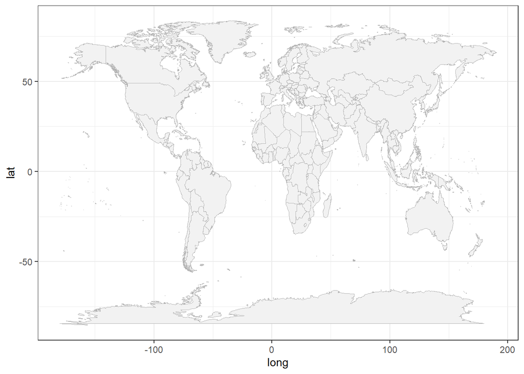

```r
gg_world
```

3. add static point plot on the world grid

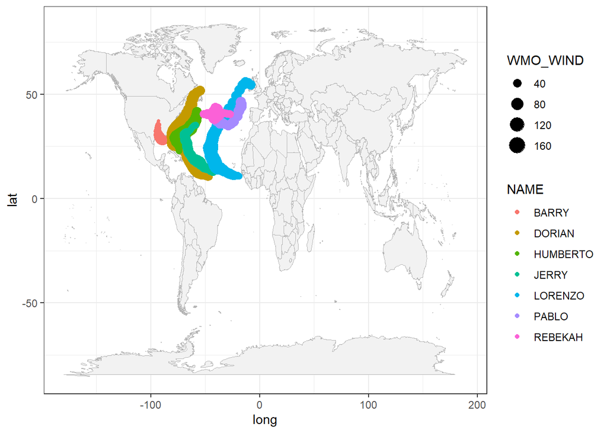

```r
gg_world +
  geom_point(data = hurricanes_2019,
             aes(x = LON, y = LAT, color = NAME, size = WMO_WIND))
```

Here, the paths are overlapped with each other, so draw each distinct graph will be visualized better like the following:

```r
hurricanes_2019_distinct = hurricanes_2019 %>%
  distinct(NAME)
hurricanes_2019_distinct
```

```
## # A tibble: 7 x 2
## # Groups:   SID [7]
##   SID           NAME
##   <chr>         <chr>
## 1 2019192N29274 BARRY
## 2 2019236N10314 DORIAN
## 3 2019256N23286 HUMBERTO
## 4 2019260N13317 JERRY
## 5 2019266N11341 LORENZO
## 6 2019297N40322 PABLO
## 7 2019300N41309 REBEKAH
```

```r
#BARRY DORIAN HUMBERTO JERRY LORENZO PABLO REBEKAH
```

4. Define each variable represent each hurricane’s plot like following:

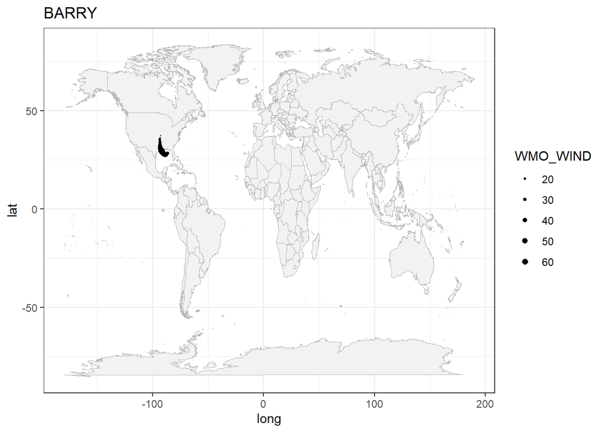

```r
barry_plot = gg_world +
          ggtitle('BARRY') +
  geom_point(data = subset(hurricanes_2019, NAME == "BARRY"),
             aes(x = LON, y = LAT, size = WMO_WIND)) +
    scale_size_continuous(range = c(0.1, 2))

barry_plot
```

```r
dorian_plot = gg_world +
          ggtitle('DORIAN') +
  geom_point(data = subset(hurricanes_2019, NAME == "DORIAN"),
             aes(x = LON, y = LAT, size = WMO_WIND)) +
    scale_size_continuous(range = c(0.5, 3))
```

```r
humberto_plot = gg_world +
          ggtitle('HUMBERTO') +
  geom_point(data = subset(hurricanes_2019, NAME == "HUMBERTO"),
             aes(x = LON, y = LAT, size = WMO_WIND)) +
    scale_size_continuous(range = c(0.5, 3))
```

```r
jerry_plot = gg_world +
          ggtitle('JERRY') +
  geom_point(data = subset(hurricanes_2019, NAME == "JERRY"),
             aes(x = LON, y = LAT, size = WMO_WIND)) +
    scale_size_continuous(range = c(0.5, 3))
```

```r
lorenzo_plot = gg_world +
          ggtitle('LORENZO') +
  geom_point(data = subset(hurricanes_2019, NAME == "LORENZO"),
             aes(x = LON, y = LAT, size = WMO_WIND)) +
    scale_size_continuous(range = c(0.5, 3))
```

```r
pablo_plot = gg_world +
          ggtitle('PABLO') +
  geom_point(data = subset(hurricanes_2019, NAME == "BARRY"),
             aes(x = LON, y = LAT, size = WMO_WIND)) +
    scale_size_continuous(range = c(0.5, 3))
```

```r
rebekah_plot = gg_world +
          ggtitle('REBEKAH') +
  geom_point(data = subset(hurricanes_2019, NAME == "REBEKAH"),
             aes(x = LON, y = LAT, size = WMO_WIND)) +
    scale_size_continuous(range = c(0.5, 3))
```

5. Load animation

```r
barry_anim = barry_plot + transition_time(ISO_TIME) +
  shadow_wake(.3) +
  ease_aes('linear')

#anim_save('barry_anim', animation = last_animation(), path = 'anims')
```

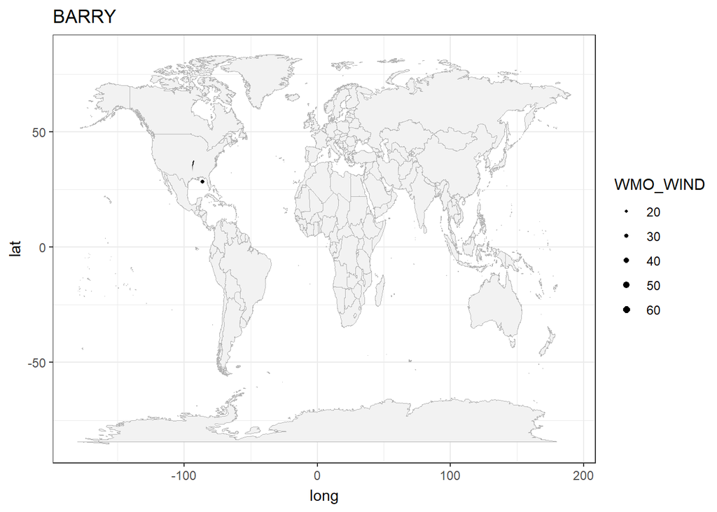

```r
barry_anim
```

- Do for the other hurricanes.

```r
dorian_anim = dorian_plot + transition_time(ISO_TIME) +
  shadow_wake(.3) +
  ease_aes('linear')

#anim_save('dorian_anim', animation = last_animation(), path = 'anims')

humberto_anim = humberto_plot + transition_time(ISO_TIME) +
  shadow_wake(.3) +
  ease_aes('linear')

#anim_save('humberto_anim', animation = last_animation(), path = 'anims')

jerry_anim = jerry_plot + transition_time(ISO_TIME) +
  shadow_wake(.3) +
  ease_aes('linear')

#anim_save('jerry_anim', animation = last_animation(), path = 'anims')

lorenzo_anim = lorenzo_plot + transition_time(ISO_TIME) +
  shadow_wake(.3) +
  ease_aes('linear')

#anim_save('lorenzo_anim', animation = last_animation(), path = 'anims')

pablo_anim = pablo_plot + transition_time(ISO_TIME) +
  shadow_wake(.3) +
  ease_aes('linear')

#anim_save('pablo_anim', animation = last_animation(), path = 'anims')

rebekah_anim = rebekah_plot + transition_time(ISO_TIME) +
  shadow_wake(.3) +
  ease_aes('linear')

#anim_save('rebekah_anim', animation = last_animation(), path = 'anims')
```

- Output animation

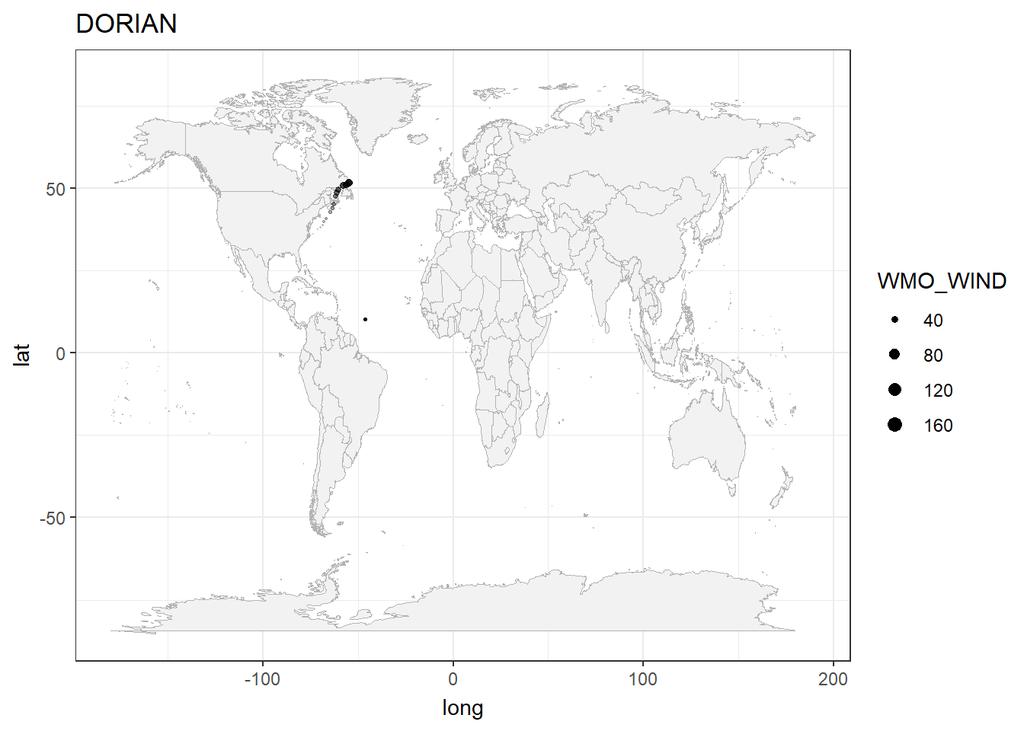

```r
dorian_anim
```

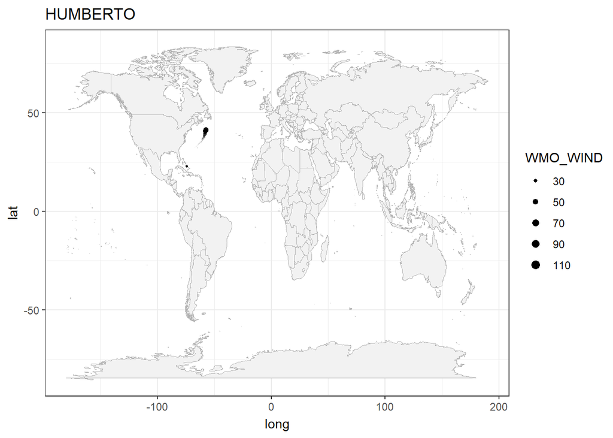

```r
humberto_anim
```

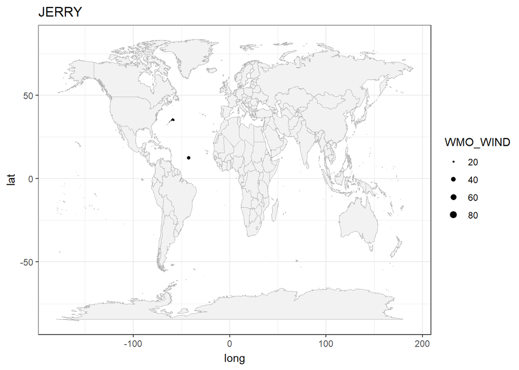

```r
jerry_anim
```

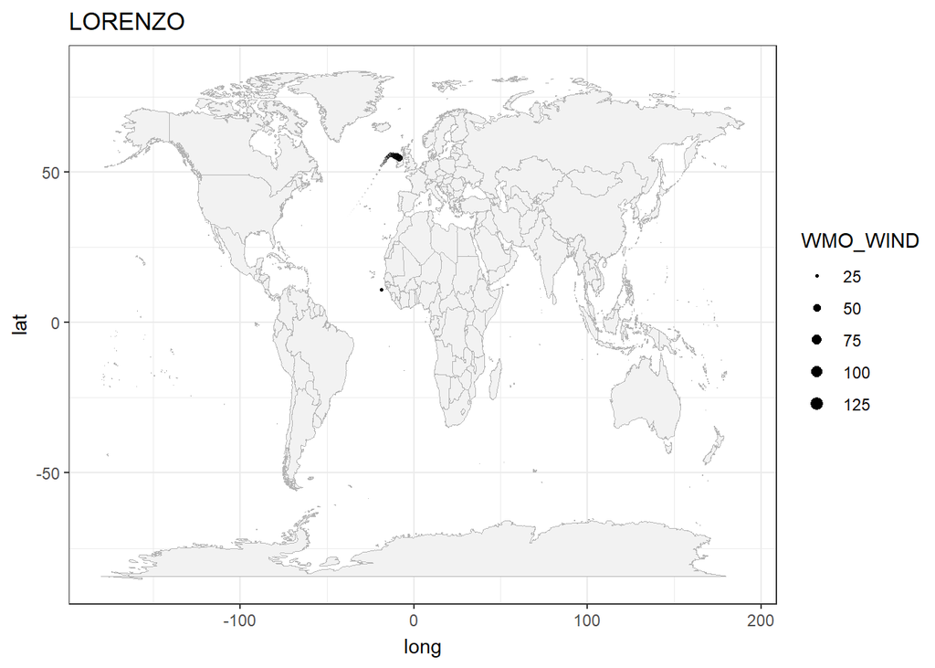

```r
lorenzo_anim
```

[figure not shown]

```r
pablo_anim
```

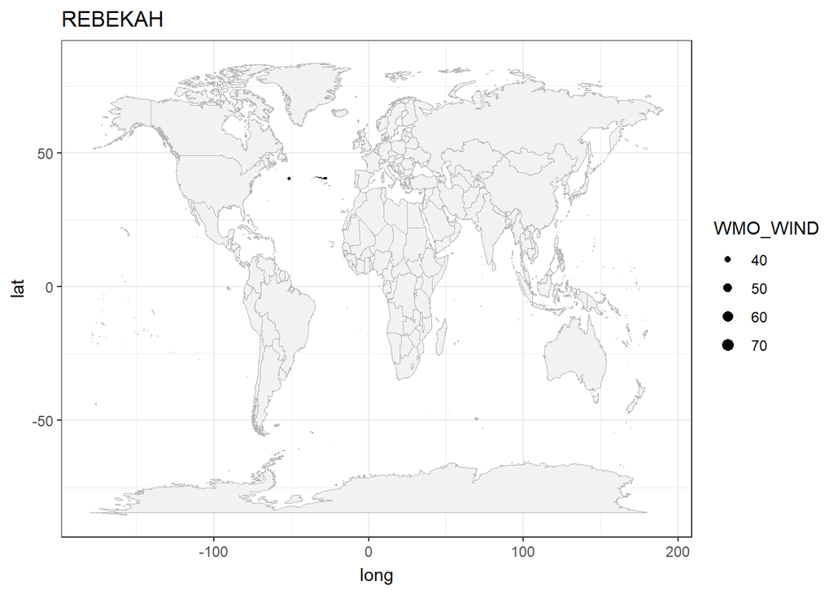

```r
rebekah_anim
```